# Community Level PCR & Bottle Variation via Bray-Curtis

M Fisher, via Helen Casendino, Joe Duprey, Kai Vennemann

1/28/2021

# Description

This script is adapted from comm_var_braycurtis.Rmd, written by Helen Casendino, Joe Duprey, Kai Vennemann.

For the lane 1 sequencing data, I am primarily interested in variability between technical replicates.

It "creates distributions of variability among technical (PCR) and biological (crab) replicates at the community level. As a metric for community variability, we apply the Bray-Curtis dissimilarity (BCD) from the vegdist() function in the vegan library.

For the biological replicate level (variation between crabs within sampling event), there is no averaging across PCRs; i.e., we are collecting pairwise BC distances among A.1, A.2, A.3, B.1, B.2, etc. To avoid tabulating intra-crab PCR variation when looking at the bio replicate level, we will only harvest pairwise distances between communities in *different* crabs, i.e., take the pairwise distance between A.1 and B.1, B.2, B.3, but not between A.1 and A.2, A.3."

# Set up

This script requires the following packages…

And calls these custom functions.

```r
source(here('R','cvt_to_PCR_props.R'))
source(here('R','find_PCR_BCDs.R'))
source(here('R','find_bottle_BCDs.R'))
```

Specify user directories

```r
indir_asv    <- 'test-lane-1/data/dada2'
indir_meta   <- 'test-lane-1/data/cutadapt'
outdir       <- 'test-lane-1/results'
```

# BF3

```r
marker <- "BF3"
```

## Step 1: Read in the data.

The data should be in a .csv file with the following columns: `seq_run`,`site`,`bio`,`tech`,`hash`,`reads`. “Bio” refers to the biological replicate (crabs), and “tech” refers to the PCR technical replicate.

This file can be created using the ASV table output from DADA2, and the sampling metadata file.

```r
dat.bf3 <- left_join(asv1,metadat1,by="Sample_name") %>%
  # remove controls
  filter(!is.na(bio)) %>%
  # format data
  mutate(seq_run=1) %>%
  rename(hash=Hash, reads=nReads) %>%
  dplyr::select(seq_run,site,bio,tech,hash,reads)
```

Some QC: check to make sure that each of the biological replicates has 2 or more PCR replicates. If not, remove that sample.

```
## removing the following sample(s) without PCR replicates: MARPT_02
```

```
## any remaining samples to remove? FALSE
```

## Step 2: Quantify variation among technical replicates.

The find_PCR_BCDs function computes the pairwise Bray-Curtis dissimilarities (BCDs) among technical replicates within each biological sample, stores all obtained values in a numeric vector, and plots those values in a histogram. The function allows the user to specify which sequence runs should be analyzed (by default, all will be used), hence the seq_runs vector parameter. Note that we first convert reads into proportions (by PCR) before calculating BCDs.

```r
PCR_output <- find_PCR_BCDs(dat.bf3)
```

```
## [1] "Bray-Curtis Dissimilarities:"
##  [1] 1.00000000 1.00000000 0.06746159 0.99936817 0.99936817 0.59404675
##  [7] 0.05914838 0.08127205 0.08730451 0.20773872 0.19019444 0.11257735
## [13] 0.20719365 0.19601290 0.17944946 0.17381513 0.17606617 0.03594181
## [19] 0.15061661 0.29278835 0.02406287 0.50273495 0.29930858 0.32444016
## [25] 0.50377298 0.13752745 0.14544107 0.05117741 0.90249112 0.90316611
## [31] 0.50020935
## [1] "Mean BCD value: 0.358216008769554"
```

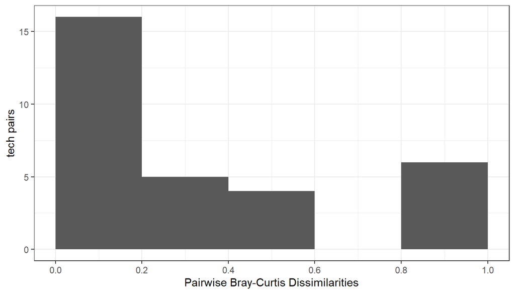

For my data, I want to know which BCDs are associated with which sample (bio) and site. I’ve adapted the function above to allow this:

```r
pairwise.dat <- PCR_output[[3]]
colnames(pairwise.dat)
```

```
## [1] "site" "bio"  "bcd"
```

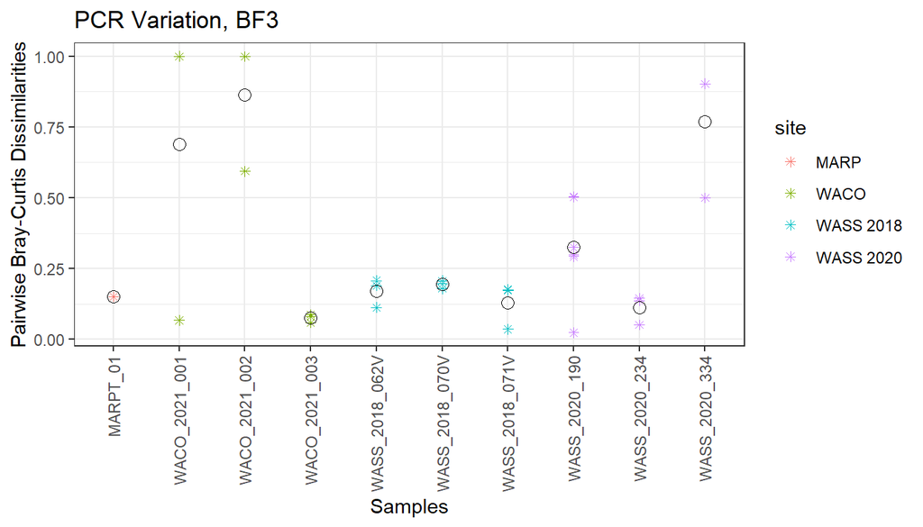

## Step 3: Quantify variation among biological replicates.

Here we create a function that computes the pairwise Bray-Curtis dissimilarities among replicates from separate bottles (but from same sampling event). We do not average across PCRs. Note that we first convert reads into proportions (by PCR) before calculating BCDs.

```r
bottle_output <- find_bottle_BCDs(dat.bf3)
```

# Leray

```r
marker <- "Leray"
```

## Step 1: Read in the data.

The data should be in a .csv file with the following columns: `seq_run`,`site`,`bio`,`tech`,`hash`,`reads`. “Bio” refers to the biological replicate (crabs), and “tech” refers to the PCR technical replicate.

This file can be created using the ASV table output from DADA2, and the sampling metadata file.

```r
dat.l <- left_join(asv2,metadat2,by="Sample_name") %>%
  # remove controls
  filter(!is.na(bio)) %>%
  # format data
  mutate(seq_run=1) %>%
  rename(hash=Hash, reads=nReads) %>%
  dplyr::select(seq_run,site,bio,tech,hash,reads)
```

Some QC: check to make sure that each of the biological replicates has 2 or more PCR replicates. If not, remove that sample.

```
## all biological replicates have at least two or more PCR replicates. data ready for processing.
```

## Step 2: Quantify variation among technical replicates.

The find_PCR_BCDs function computes the pairwise Bray-Curtis dissimilarities (BCDs) among technical replicates within each biological sample, stores all obtained values in a numeric vector, and plots those values in a histogram. The function allows the user to specify which sequence runs should be analyzed (by default, all will be used), hence the seq_runs vector parameter. Note that we first convert reads into proportions (by PCR) before calculating BCDs.

```r
PCR_output.l <- find_PCR_BCDs(dat.l)
```

```
## [1] "Bray-Curtis Dissimilarities:"
##  [1] 0.997381253 0.997925439 0.182452347 1.000000000 1.000000000 0.249222435
##  [7] 0.949606530 0.949606530 0.042120404 0.969950244 0.973119830 0.182377173
## [13] 0.964518276 0.964518276 0.012818710 0.077869285 0.044039259 0.048016305
## [19] 0.121650445 0.008499799 0.348119073 0.347829611 0.094189322 0.242191630
## [25] 0.275328834 0.085515548 0.165618510 0.203821884
## [1] "Mean BCD value: 0.446368105466437"
```

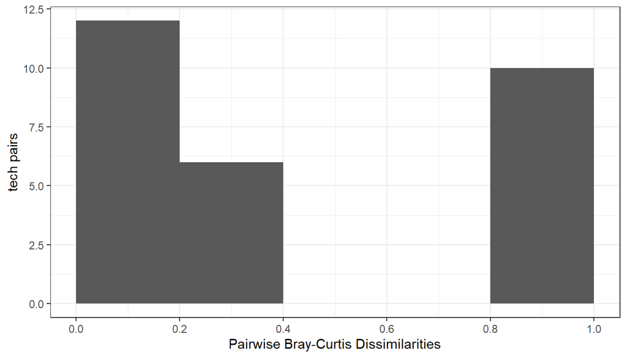

For my data, I want to know which BCDs are associated with which sample (bio) and site. I’ve adapted the function above to allow this:

```r
pairwise.dat.l <- PCR_output.l[[3]]
colnames(pairwise.dat.l)
```

```
## [1] "site" "bio"  "bcd"
```

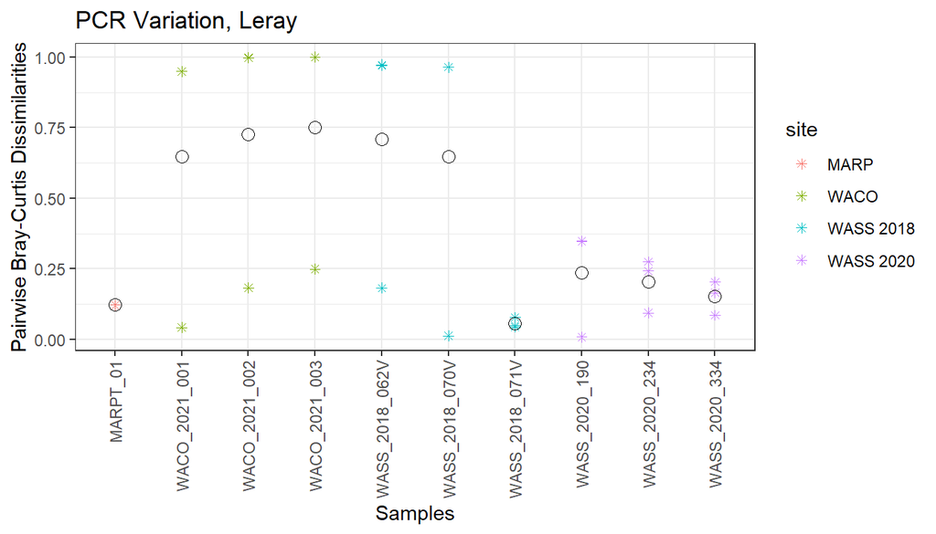

## Step 3: Quantify variation among biological replicates.

Here we create a function that computes the pairwise Bray-Curtis dissimilarities among replicates from separate bottles (but from same sampling event). We do not average across PCRs. Note that we first convert reads into proportions (by PCR) before calculating BCDs.

```r
bottle_output <- find_bottle_BCDs(dat.bf3)
```

# LerayXT

```r
marker <- "LerayXT"
```

## Step 1: Read in the data.

The data should be in a .csv file with the following columns: `seq_run`,`site`,`bio`,`tech`,`hash`,`reads`. “Bio” refers to the biological replicate (crabs), and “tech” refers to the PCR technical replicate.

This file can be created using the ASV table output from DADA2, and the sampling metadata file.

```r
dat.lxt <- left_join(asv3,metadat3,by="Sample_name") %>%
  # remove controls
  filter(!is.na(bio)) %>%
  # format data
  mutate(seq_run=1) %>%
  rename(hash=Hash, reads=nReads) %>%
  dplyr::select(seq_run,site,bio,tech,hash,reads)
```

Some QC: check to make sure that each of the biological replicates has 2 or more PCR replicates. If not, remove that sample.

```
## all biological replicates have at least two or more PCR replicates. data ready for processing.
```

## Step 2: Quantify variation among technical replicates.

The find_PCR_BCDs function computes the pairwise Bray-Curtis dissimilarities (BCDs) among technical replicates within each biological sample, stores all obtained values in a numeric vector, and plots those values in a histogram. The function allows the user to specify which sequence runs should be analyzed (by default, all will be used), hence the seq_runs vector parameter. Note that we first convert reads into proportions (by PCR) before calculating BCDs.

```r
PCR_output.lxt <- find_PCR_BCDs(dat.lxt)
```

```
## [1] "Bray-Curtis Dissimilarities:"
##  [1] 1.00000000 1.00000000 0.02547765 0.02486618 1.00000000 1.00000000
##  [7] 0.07811668 0.97718418 0.97820636 0.08896055 0.99464797 0.99479341
## [13] 0.09858367 0.99644655 0.99614693 0.02558389 0.21506809 0.20572631
## [19] 0.05481169 0.16712022 0.14053490 0.04695826 0.74503265 0.74478468
## [25] 0.20033653 0.72995179 0.74237939 0.10967527 0.22281497
## [1] "Mean BCD value: 0.503593406097927"
```

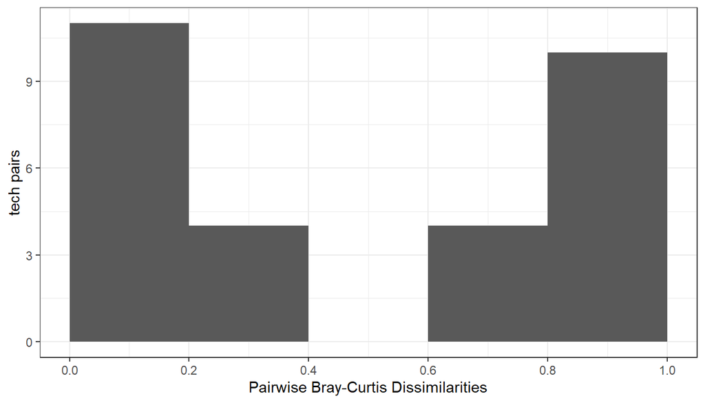

For my data, I want to know which BCDs are associated with which sample (bio) and site. I’ve adapted the function above to allow this:

```r
pairwise.dat.lxt <- PCR_output.lxt[[3]]
colnames(pairwise.dat.lxt)
```

```
## [1] "site" "bio"  "bcd"
```

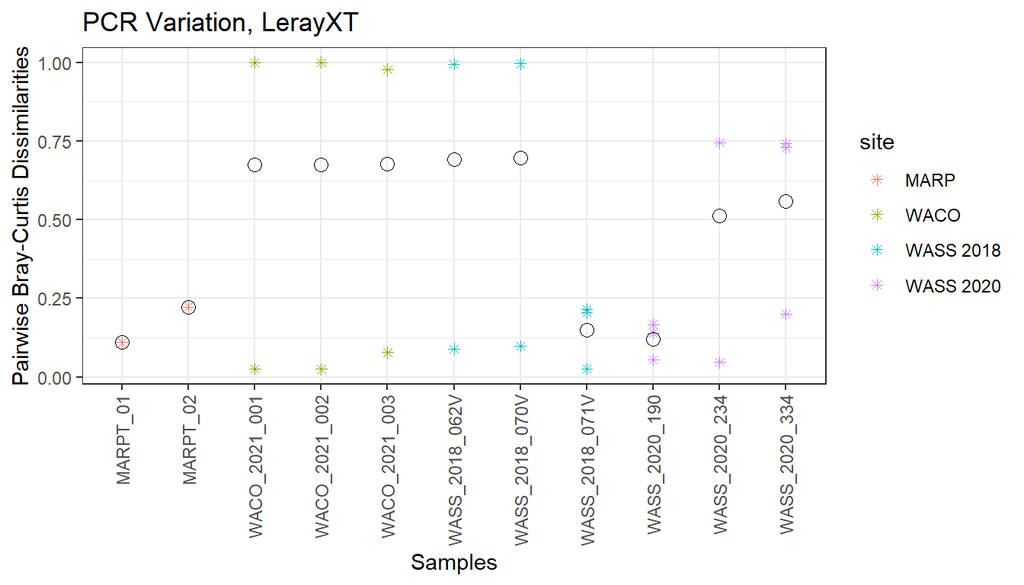

## Step 3: Quantify variation among biological replicates.

Here we create a function that computes the pairwise Bray-Curtis dissimilarities among replicates from separate bottles (but from same sampling event). We do not average across PCRs. Note that we first convert reads into proportions (by PCR) before calculating BCDs.

```r
bottle_output <- find_bottle_BCDs(dat.bf3)
```

# Compare PCR Var

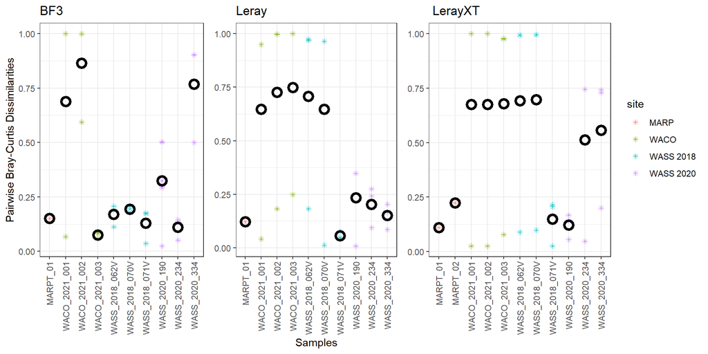

## WACO switched

Exploring the Blast output, it looks like the following WACO samples were switched with the kangaroo positive control:

- WACO.2021.001a (BF3, LerayXT)
- WACO.2021.002a (Leray)

I can’t find anything in my lab notes that suggests that the indexes were actually switched between these samples, but I’m curious to see how it affects PCR variability.

Edit BF3 data

```
## # A tibble: 1 x 5
##   Sample_name SampleID       bio            tech site
##         <dbl> <chr>          <chr>         <dbl> <chr>
## 1          95 WACO_2021_001a WACO_2021_001     1 WACO
```

```
## removing the following sample(s) without PCR replicates: MARPT_02
```

```
## any remaining samples to remove? FALSE
```

Edit Leray data

```
## # A tibble: 1 x 5
##   Sample_name SampleID       bio            tech site
##         <dbl> <chr>          <chr>         <dbl> <chr>
## 1          99 WACO_2021_002a WACO_2021_002     1 WACO
```

```
## all biological replicates have at least two or more PCR replicates. data ready for processing.
```

Edit LerayXT data

```
## # A tibble: 1 x 5
##   Sample_name SampleID       bio            tech site
##         <dbl> <chr>          <chr>         <dbl> <chr>
## 1          96 WACO_2021_001a WACO_2021_001     1 WACO
```

```
## all biological replicates have at least two or more PCR replicates. data ready for processing.
```

Re-run the function `find_PCR_BCDs` for each marker

```r
PCR_output.b2 <- find_PCR_BCDs(dat.bf3)
```

```
## [1] "Bray-Curtis Dissimilarities:"
##  [1] 0.06746159 0.99591998 0.99587505 0.99936817 0.99936817 0.59404675
##  [7] 0.05914838 0.08127205 0.08730451 0.20773872 0.19019444 0.11257735
## [13] 0.20719365 0.19601290 0.17944946 0.17381513 0.17606617 0.03594181
## [19] 0.15061661 0.29278835 0.02406287 0.50273495 0.29930858 0.32444016
## [25] 0.50377298 0.13752745 0.14544107 0.05117741 0.90249112 0.90316611
## [31] 0.50020935
## [1] "Mean BCD value: 0.357951332344408"
```

```r
pairwise.dat.b2 <- PCR_output.b2[[3]]
PCR_output.l2 <- find_PCR_BCDs(dat.l)
```

```
## [1] "Bray-Curtis Dissimilarities:"
##  [1] 0.182452347 1.000000000 0.993617617 1.000000000 1.000000000 0.249222435
##  [7] 0.949606530 0.949606530 0.042120404 0.969950244 0.973119830 0.182377173
## [13] 0.964518276 0.964518276 0.012818710 0.077869285 0.044039259 0.048016305
## [19] 0.121650445 0.008499799 0.348119073 0.347829611 0.094189322 0.242191630
## [25] 0.275328834 0.085515548 0.165618510 0.203821884
## [1] "Mean BCD value: 0.446307781344035"
```

```r
pairwise.dat.l2 <- PCR_output.l2[[3]]
PCR_output.lxt2 <- find_PCR_BCDs(dat.lxt)
```

```
## [1] "Bray-Curtis Dissimilarities:"
##  [1] 0.02547765 1.00000000 1.00000000 0.02486618 1.00000000 1.00000000
##  [7] 0.07811668 0.97718418 0.97820636 0.08896055 0.99464797 0.99479341
## [13] 0.09858367 0.99644655 0.99614693 0.02558389 0.21506809 0.20572631
## [19] 0.05481169 0.16712022 0.14053490 0.04695826 0.74503265 0.74478468
## [25] 0.20033653 0.72995179 0.74237939 0.10967527 0.22281497
## [1] "Mean BCD value: 0.503593406097927"
```

```r
pairwise.dat.lxt2 <- PCR_output.lxt2[[3]]
```

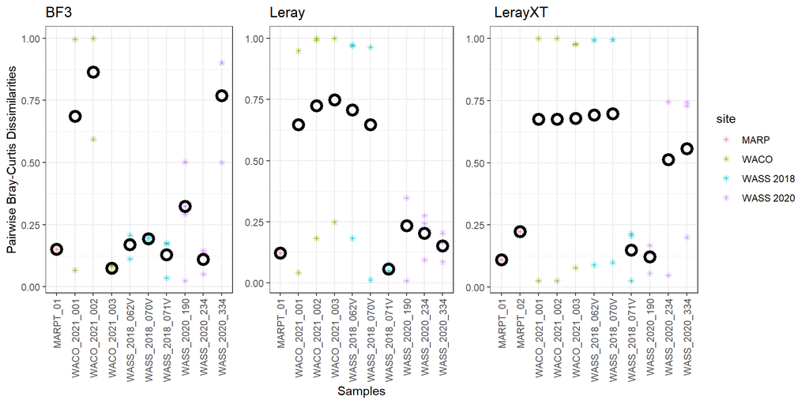

# Compare Bio Var

## WACO-MARPT switched

Exploring the Blast output, the following WACO samples had large amounts of Dungy DNA:

- **BF3**: WACO.2021.001b/c and WACO2021.002a (MARPT.01a/b and MARPT.02a in data set)
- **Leray**: WACO.2021.002a/b/c (MARPT.01a/b in data set)
- **LerayXT**: WACO.2021.001b/c and WACO2021.002a/b (MARPT.01a/b and MARPT.02a/b in data set)

I can’t find anything in my lab notes that suggests that the indexes were actually switched between these samples, but I’m curious to see how it affects Biological Replicate variability.